# 1. 단어중요도 (TF-IDF)- DTM 알고리즘의 이해_문서내의 단어빈도수 계산

```python
import warnings
warnings.filterwarnings(action='ignore')
```

### 텍스트 마이닝에서 단어 가중치 계산방법중 한가지인 TF-IDF를 이해하기 위하여 1,2번 파일을 학습합니다.

- 1,2 파일은 내용은 이해만 해도 됨. (직접 수식을 작성하지 않아도 되게끔 사이킷런에서 TfidfVectorizer 패키지를 제공함)
- '1. 단어중요도 (TF-IDF)- DTM 알고리즘의 이해_문서내의 단어빈도수 계산.html'
- '2. 단어중요도 (TF-IDF) - TF-IDF를 이용한 문서내의 단어중요도 체크.html'
- '3. 단어중요도 (TF-IDF) 및 문장유사 예측- 사이킷런 패키지 활용.hmtl' ===> 이 자료만 실행하면 됨
- 정보 검색 등에서 단어의 가중치 계산하는 방법 중 가장 기본이 되는 방법중 하나인 TFIDF 에 대하여 이해하고자함.
- '단어가 일반적인 것인가 전문적인 것인가'를 살펴보는 척도, TF-IDF값이 크면 어떤 한 분야에 전문적인 용어임.

## DTM (Document Term Matrix)

- DTM: 문서(Document)별의 단어(Term) 출현 빈도수(TF)를 가로 세로의 행열(matrix) 단위로 표시한 자료
- TF(Term Frequency): 어떤 단어가 특정 문서에 얼마나 많이 쓰였는지의 횟수

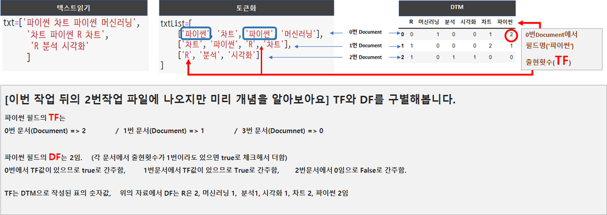

```python
# 코드의 편의성을 위해서 txt자료는 빈칸단위로 분리할수 있는 자료로 준비했습니다.
txt=['파이썬 차트 파이썬 머신러닝',
      '차트 파이썬 R 차트',
       'R 분석 시각화'
      ]
```

### [Part1] DTM 제작원리 이해

- Part1은 DTM 알고리즘의 이해를 위한 작업임
- 이자료 가장 하단의 Part2 에 간단한 계산식 있음

#### Part 1-1 (단어필드제작- 문장의 토큰화)

- 단어의 정규화등 많은 작업이 필요하나 여기서는 작업의 편의성을 위해 빈칸단위로 분리한 자료로 사용함.
- 토큰화는 기존의 워드클라우드 작업과 동일함.

```python
############################
##  [방법1] 빈칸단위로 나누기
###############################
txtList=[]
for x in txt:
    list_=[]

    for j in x.split(' '):
        list_.append(j)
    txtList.append(list_)

display(txtList)
```

```
[['파이썬', '차트', '파이썬', '머신러닝'], ['차트', '파이썬', 'R', '차트'], ['R', '분석', '시각화']]
```

```python
############################
##  [방법2] 데이터 나누기 컴프리헨션
###############################
tmp=[x.split(' ') for x in txt]
tmp
```

```
[['파이썬', '차트', '파이썬', '머신러닝'], ['차트', '파이썬', 'R', '차트'], ['R', '분석', '시각화']]
```

#### Part 1-1 (단어필드제작- 단어 1차원 자료로)

- 중복단어를 제거하여 고유값으로 필드를 제작해야함.

```python
############################
##  [방법1]
###############################
import numpy as np

dataList=[]
for i in txtList:
    for j in i:
        dataList.append(j)
dataList
```

```
['파이썬', '차트', '파이썬', '머신러닝', '차트', '파이썬', 'R', '차트', 'R', '분석', '시각화']
```

```python
############################
##  [방법2] 2차원 리스트 1차원 결합 컴프리헨션
###############################

tmpList=[x for row in tmp for x in row]
tmpList
```

```
['파이썬', '차트', '파이썬', '머신러닝', '차트', '파이썬', 'R', '차트', 'R', '분석', '시각화']
```

```python
############################
##  [방법3] 넘파이를 이용하여서 한개의 리스트로 제작가능
###############################
np.concatenate(np.array(tmp))
```

```
array(['파이썬', '차트', '파이썬', '머신러닝', '차트', '파이썬', 'R', '차트', 'R', '분석',
       '시각화'], dtype='<U4')
```

#### Part 1-3 (단어필드제작- 단어 unique)

```python
############################
##  [방법1] 중복제거, 이 작업은 중복제거 되지만 sort는 되지 않음.
###############################

uniqueList=[]

for i in dataList:
    cnt=1
    for j in uniqueList:
        if i==j:
            cnt+=1
    if cnt==1:
        uniqueList.append(i)
uniqueList
```

```
['파이썬', '차트', '머신러닝', 'R', '분석', '시각화']
```

```python
############################
##  [방법1]  넘파이 제공 unique함수 사용
## 이 unique함수에 대한 기술은 아래 사이트에서 확인하면 됨
##  아래 사이트 검색은 구글에서 '넘파이 unique py' 로 검색한 메뉴얼 에서 우측 상단의 source 클릭하여서 나옴
## https://github.com/numpy/numpy/blob/v1.21.0/numpy/lib/arraysetops.py#L138-L317
## 위의 사이트에 보면  가장 상단의 uniuqe를 제공하는 라이브러리 위치 있음.
##   /numpy/lib/arraysetops.py /    => 로컬PC의 경우 넘파이 설치된 패키지의 lib 폴더에서 확인가능
## 예: 강사용 pc   ==>  C:\Users\TECH-8\anaconda3\Lib\site-packages\numpy\lib
###############################
uniqueList=np.unique(dataList)
uniqueList
```

```
array(['R', '머신러닝', '분석', '시각화', '차트', '파이썬'], dtype='<U4')
```

```python
############################
##  [방법2] sort (파이썬 자료 구조 찾아서 해보세요)
## 이 방법이 바로 unique함수를 만드는 것임.
# https://getchan.github.io/algorithm/python_algo_9/
###############################


# http://localhost:8889/notebooks/Desktop/%ED%94%84%EB%A1%9C%EC%A0%9D%ED%8A%B8/1.%20%ED%85%8D%EC%8A%A4%ED%8A%B8%20%EB%B9%88%EB%8F%84%EC%88%98%20%EA%B3%84%EC%82%B0.ipynb#[-%EB%8B%A8%EC%96%B4%ED%95%84%EB%93%9C%EC%A0%9C%EC%9E%91--4.-%EB%8B%A8%EC%96%B4-%ED%95%84%EB%93%9C%EC%9E%91%EC%84%B1]
```

#### Part 1-4 (단어필드제작- 단어 필드작성)

- uniqueList 를 이용

```python
import pandas as pd

# 단어필드 작성을 위해서는 아래의 두개 자료가 필요함.
print(uniqueList)
# print(txtList)
```

```
['R' '머신러닝' '분석' '시각화' '차트' '파이썬']
```

#### Part 1-5 (DTM: 단어별 count)

```python
######################################
## 1개의 컬럼만 출현횟수를 먼저 계산하여 봅니다.
## txtList는 아래와 같습니다.
##  [['파이썬', '차트', '파이썬', '머신러닝'],
##    ['차트', '파이썬', 'R', '차트'],
##   ['R', '분석', '시각화']]
#####################################
## 참고, 아래의 경우 uniqueList의 첫단어를 1번행에서만 확인한 결과임. [1행 1열의 값을  보여줌]



col=uniqueList[0]   # 리스트의처음값 'R'로 보기
print('▶ 검색단어==> %s'%col)

row=txtList[0]   # 1번행에서만 확인하기
print('▶ 검색대상 1행 ==> %s'%row)

cnt=0
for item in row:
    if col==item:
        cnt=cnt+1
print('▶▶▶ 검색단어: %s   검색된횟수: %d' %(col,cnt))
```

```
▶ 검색단어==> R
▶ 검색대상 1행 ==> ['파이썬', '차트', '파이썬', '머신러닝']
▶▶▶ 검색단어: R   검색된횟수: 0
```

```python
### -- DTM 계산
######################################
### 컬럼자료의 출현횟수를 계산함.
### [방법1] 직접작성
### 위의 코드를 다중 for로 완성
###################################
result=[]

for col in uniqueList:   # 리스트의처음값 'R'로 보기
    list_=[]
    for row in txtList:      #1번행에서 확인
        cnt=0

        for item in row:
            if col==item:
                cnt=cnt+1
        # print('------------------------------')
        #print('검색단어: %s   검색된횟수: %d' %(col,cnt))

        list_.append(cnt)
    result.append(list_)

df = pd.DataFrame(result)
print(df)
print('--------------------------')
df=df.T
print(df)
df.columns = uniqueList

df
```

```
   0  1  2
0  0  1  1
1  1  0  0
2  0  0  1
3  0  0  1
4  1  2  0
5  2  1  0
--------------------------
   0  1  2  3  4  5
0  0  1  0  0  1  2
1  1  0  0  0  2  1
2  1  0  1  1  0  0
```

|  | R | 머신러닝 | 분석 | 시각화 | 차트 | 파이썬 |
| --- | --- | --- | --- | --- | --- | --- |
| 0 | 0 | 1 | 0 | 0 | 1 | 2 |
| 1 | 1 | 0 | 0 | 0 | 2 | 1 |
| 2 | 1 | 0 | 1 | 1 | 0 | 0 |

```python
######################################
### 참고: 장바구니분석(연관분석)에 사용하는 자료는 자료의 출현여부만 확인함.
### [방법1] 직접작성
#####################################

result=[]
for data in txtList:

    list_=['True'   if x in data  else 'False' for x in uniqueList]
    result.append(list_)
result

pd.DataFrame(result,columns=uniqueList)
```

|  | R | 머신러닝 | 분석 | 시각화 | 차트 | 파이썬 |
| --- | --- | --- | --- | --- | --- | --- |
| 0 | False | True | False | False | True | True |
| 1 | True | False | False | False | True | True |
| 2 | True | False | True | True | False | False |

```python
######################################
### 참고: 장바구니분석(연관분석)에 사용하는 자료는 자료의 출현여부만 확인함.
### [방법2] transactionEncoder 모듈 사용
#####################################

from mlxtend.preprocessing import TransactionEncoder

te = TransactionEncoder()
te.fit(txtList)
print(te.columns_)    # 중복제거한 컬러명 출력

print('--------------------------------------------')
te_ary = te.fit(txtList).transform(txtList)
print(te_ary)

df = pd.DataFrame(te_ary, columns=te.columns_)
df
```

```
['R', '머신러닝', '분석', '시각화', '차트', '파이썬']
--------------------------------------------
[[False  True False False  True  True]
 [ True False False False  True  True]
 [ True False  True  True False False]]
```

|  | R | 머신러닝 | 분석 | 시각화 | 차트 | 파이썬 |
| --- | --- | --- | --- | --- | --- | --- |
| 0 | False | True | False | False | True | True |
| 1 | True | False | False | False | True | True |
| 2 | True | False | True | True | False | False |

### [Part2] DTM 제작간단히code

- https://wikidocs.net/31698
- 위의 위키문서는 텍스트분석에 대하여 아주 잘 서술된 자료입니다. 이 자료를 기반으로
- 2번에서 TF-IDF를 제작하여 보겠습니다.

```python
txt=['파이썬 차트 파이썬 머신러닝',
      '차트 파이썬 R 차트',
       'R 분석 시각화'
      ]

vocab = list(set(w for doc in  txt for w in doc.split()))
vocab.sort()
vocab
```

```
['R', '머신러닝', '분석', '시각화', '차트', '파이썬']
```

```python
def tf(t, d):
    return d.count(t)
```

```python
result = []
N=len(txt)
for i in range(N): # 각 문서에 대해서 아래 명령을 수행
    result.append([])
    d = txt[i]
    for j in range(len(vocab)):
        t = vocab[j]
        result[-1].append(tf(t, d))

tf_ = pd.DataFrame(result, columns = vocab)
tf_
```

|  | R | 머신러닝 | 분석 | 시각화 | 차트 | 파이썬 |
| --- | --- | --- | --- | --- | --- | --- |
| 0 | 0 | 1 | 0 | 0 | 1 | 2 |
| 1 | 1 | 0 | 0 | 0 | 2 | 1 |
| 2 | 1 | 0 | 1 | 1 | 0 | 0 |